# Exploratory Data Analysis of the CDC’s ‘500 Cities Project’ - Part 2

# Introduction

In [Part 1](https://redoakstrategic.com/exploratory_data_analysis_cdc_500_cities_r_shiny/), we built an application to geographically explore the [*500 Cities Project dataset*](https://www.cdc.gov/500cities/) from the CDC. In this post, we will demonstrate other exploratory data analysis (EDA) techniques for exploring a new dataset. The analysis will be done with R packages *data.table*, *ggplot2* and *highcharter*.

In this post, you will learn how to:

- Build a boxplot
- Build and plot a correlation matrix
- Build a histogram

# Load Dataset

It may take a few minutes to download the data. The data is also available [here.](https://chronicdata.cdc.gov/500-Cities/500-Cities-Local-Data-for-Better-Health-2017-relea/6vp6-wxuq)

```r
library(data.table)
df <- fread('https://chronicdata.cdc.gov/api/views/6vp6-wxuq/rows.csv?accessType=DOWNLOAD')
```

```
##
Read 79.0% of 810103 rows
Read 810103 rows and 24 (of 24) columns from 0.212 GB file in 00:00:03
```

The dataset contains values from cities across the country for 28 separate health measures. The full measure names are cumbersome so for the remainder of the post, we will use the Short_Question_Text which is an abbreviated form of the full measure name. Here are the full measure names and their corresponding abbreviations for reference.

```
##                                     Measure            Short_Question_Text
## 1  Current lack of health insurance among a               Health Insurance
## 2    Arthritis among adults aged >=18 Years                      Arthritis
## 3  Binge drinking among adults aged >=18 Ye                 Binge Drinking
## 4  High blood pressure among adults aged >=            High Blood Pressure
## 5  Taking medicine for high blood pressure            Taking BP Medication
## 6  Cancer (excluding skin cancer) among adu           Cancer (except skin)
## 7  Current asthma among adults aged >=18 Ye                 Current Asthma
## 8  Coronary heart disease among adults aged         Coronary Heart Disease
## 9  Visits to doctor for routine checkup wit                 Annual Checkup
## 10 Cholesterol screening among adults aged           Cholesterol Screening
## 11 Fecal occult blood test, sigmoidoscopy,     Colorectal Cancer Screening
## 12 Chronic obstructive pulmonary disease am                           COPD
## 13 Physical health not good for >=14 days a                Physical Health
## 14 Older adult men aged >=65 Years who are  Core preventive services for o
## 15 Older adult women aged >=65 Years who ar Core preventive services for o
## 16 Current smoking among adults aged >=18 Y                Current Smoking
## 17 Visits to dentist or dental clinic among                   Dental Visit
## 18 Diagnosed diabetes among adults aged >=1                       Diabetes
## 19 High cholesterol among adults aged >=18                High Cholesterol
## 20 Chronic kidney disease among adults aged         Chronic Kidney Disease
## 21 No leisure-time physical activity among             Physical Inactivity
## 22 Mammography use among women aged 50–74 Y                    Mammography
## 23 Mental health not good for >=14 days amo                  Mental Health
## 24     Obesity among adults aged >=18 Years                        Obesity
## 25 Papanicolaou smear use among adult women                 Pap Smear Test
## 26 Sleeping less than 7 hours among adults                 Sleep < 7 hours
## 27      Stroke among adults aged >=18 Years                         Stroke
## 28 All teeth lost among adults aged >=65 Ye                     Teeth Loss
```

# Boxplots

Boxplots graphically depict groups of numerical data through their quartiles. Outliers are shown as points above and below the boxes. This is a good first step in EDA because it shows the range of values associated with each measure. Here we will build a boxplot for each measure in the dataset grouped by category. Each boxplot is built from 500 values, one value for each city.

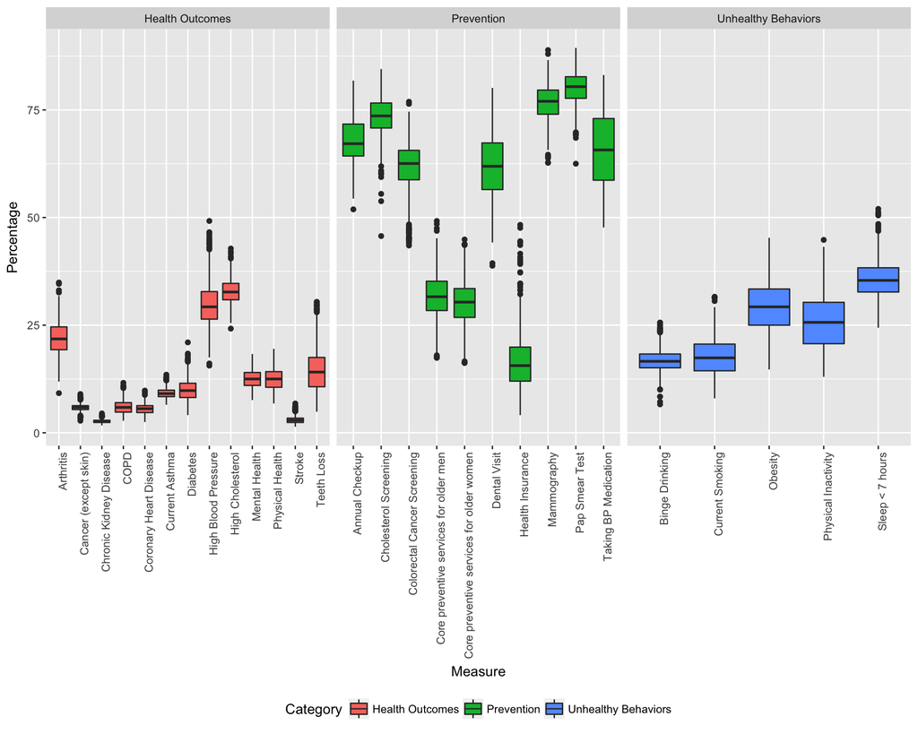

```r
library(ggplot2)
df_subset <- df[df$GeographicLevel == 'City',]

# grouped boxplot
ggplot(df_subset, aes(x=substr(Short_Question_Text, 1,40), y=Data_Value, fill = Category )) +
    geom_boxplot() +
  theme(axis.text.x = element_text(angle = 90, hjust = 1), legend.position = 'bottom') +
  facet_wrap(~Category,scales = "free_x") + xlab('Measure') + ylab('Percentage')
```

The boxplots show a wide distribution for most of the measures, especially among the preventive measures. Next we will analyze dependence between measures.

# Correlation Plot

The second EDA technique we will demonstrate is a correlation plot which is used to show dependence between measures. The correlation between measures is given by a number between -1 and 1 (1 means perfectly positively correlated and -1 means perfectly negatively correlated). The dataset contains values for each measure at three different geographic levels: US, City, and Census Tract. To compute the correlations, we will use data at the Census Tract level which is the smallest geographic level. The correlation plot will compare the measure values at each Census Tract to determine their correlation coefficient.

The steps to compute a correlation matrix in R are as follows:

- Subset the dataset to select only the necessary columns
- Convert the dataset to a wide-format
- Calculate correlations
- Plot the correlation matrix

## Subset the dataset

We only want the location (UniqueID), the measure (Short_Question_Text) and the value (Data_Value) columns in our dataset. We only want rows where GeographicLevel is Census Tract. We subset the dataset to remove the rows and columns which aren’t relevant to our analysis.

```r
df_subset <- df[GeographicLevel == 'Census Tract', c('UniqueID','Short_Question_Text', 'Data_Value')]
head(df_subset)
```

```
##               UniqueID Short_Question_Text Data_Value
## 1: 0107000-01073000100    Health Insurance       23.9
## 2: 0107000-01073000300    Health Insurance       28.8
## 3: 0107000-01073000400    Health Insurance       26.1
## 4: 0107000-01073000500    Health Insurance       28.1
## 5: 0107000-01073000700    Health Insurance       31.8
## 6: 0107000-01073000800    Health Insurance       22.4
```

## Convert to Wide Format

The R correlation function *cor()* requires that the dataset is in wide-format. The dcast function from the *data.table* package simplies the task of converting the dataset into wide-format. Essentially, the dcast function creates a new column for each unique Short_Question_Text (i.e. it ‘casts’ the Short_Question_Text into wide format) and inputs the Data_Value as the value for that column. The UniqueID is designated as the row name because it is not actually part of the correlation calculation.

```r
df_wide <- dcast(df_subset, UniqueID ~ Short_Question_Text, value.var = 'Data_Value')
row.names(df_wide) <- df_wide$UniqueID
df_wide$UniqueID <- NULL
df_wide <- df_wide[complete.cases(df_wide),] #Removes any rows with NA values
head(df_wide[,1:5])
```

```
##    Annual Checkup Arthritis Binge Drinking COPD Cancer (except skin)
## 1:           76.3      32.5           10.1 11.0                  5.2
## 2:           73.8      31.3           10.8 10.7                  4.6
## 3:           77.5      34.6            9.5 11.7                  5.2
## 4:           78.8      37.8            8.6 13.2                  5.8
## 5:           78.7      38.5            7.4 15.2                  5.7
## 6:           80.9      38.0            8.9 11.2                  6.6
```

## Compute Correlation Matrix

Now that the data is in the appropriate format, we can use the R function *cor()* to compute the correlations. We apply the *cor()* function to the wide-format data to compute the correlation between measures.

```r
cor_plot <- cor(df_wide)
cor_plot <- round(cor_plot, 2)
head(cor_plot[,1:5])
```

```
##                       Annual Checkup Arthritis Binge Drinking  COPD
## Annual Checkup                  1.00      0.61          -0.38  0.37
## Arthritis                       0.61      1.00          -0.62  0.80
## Binge Drinking                 -0.38     -0.62           1.00 -0.64
## COPD                            0.37      0.80          -0.64  1.00
## Cancer (except skin)            0.46      0.65          -0.26  0.21
## Cholesterol Screening           0.52      0.27           0.04 -0.23
##                       Cancer (except skin)
## Annual Checkup                        0.46
## Arthritis                             0.65
## Binge Drinking                       -0.26
## COPD                                  0.21
## Cancer (except skin)                  1.00
## Cholesterol Screening                 0.72
```

As you can see, the output is a dataframe with values between 1 and -1. We will plot this result to make it easier to understand and analyze.

## Plot the Correlation Matrix with Highcharts

*Highcharter* is an R wrapper for the *Highcharts* library. *Highcharts* is a data visualization library which makes it simple to develop interactive charts. The *hchart()* function can be applied to the R correlation function output to build a correlation plot.

```r
library(highcharter)
hchart(cor_plot)
```

[interactive chart not shown]

## Reorder the Correlation Plot

While this is better than the tabular form, we can make it more clear by grouping correlated features together. We will use a helper function which I found [here](http://www.sthda.com/english/wiki/ggplot2-quick-correlation-matrix-heatmap-r-software-and-data-visualization) to reorder the correlation plot.

```r
reorder_cormat <- function(cormat){
# Use correlation between variables as distance
dd <- as.dist((1-cormat)/2)
hc <- hclust(dd)
cormat <-cormat[hc$order, hc$order]
}

cor_plot <- reorder_cormat(cor_plot)
hchart(cor_plot)
```

[interactive chart not shown]

The correlation plot yields some interesting insights. The first thing I noticed is that binge drinking is negatively correlated with many of the poor health outcomes (e.g. obesity, high cholesterol, stroke, diabetes). My first thought on this is that binge drinking is more common among young people who generally don’t have as many health issues as older people. However we would need to analyze data on binge drinking more extensively to derive solid conclusions.

Another insight is lack of health insurance is positively correlated with negative health outcomes (i.e. people without health insurance experience worse health outcomes). This is interesting although not surprising. In the next section, we will drill into the health insurance measure to analyze how it differs across the nation.